# Сводный контроль размеченных сигналов эксперимента 2

**Задача:** объединить принятые дыхательные интервалы `11.01`, принятые R-зубцы `11.02` и поканальные ограничения `10.01`, после чего определить, какие наблюдаемые уровни и сердечные циклы можно передавать в последующие расчёты.

Ноутбук выполняет технический и временной контроль. Он не восстанавливает удельное сопротивление тканей, не оценивает толщину мягких тканей и не решает обратную задачу. Амплитуды `RHEO2` используются только как диагностические характеристики в единицах исходного файла.

## Входы, решения и ограничения

Обязательными входами являются 19 независимых записей размерного ряда, принятые дыхательные и ЭКГ-разметки, а также покомпонентный манифест `10.01`. Запись Ника 100 мм не получает самостоятельного статистического веса. Для Георга 90 и 100 мм канал 1 и совместный анализ каналов исключены, тогда как `BASE2` и `RHEO2` проверяются отдельно.

Наблюдаемые уровни `BASE1` и `BASE2` рассчитываются как медианы внутри принятых задержек после удаления 0,5 с у каждой границы. Эти значения остаются показаниями прибора: абсолютная калибровка, межканальное влияние и связь с удельным сопротивлением тканей не установлены.

Полным сердечным циклом считается интервал между соседними принятыми R-зубцами. В анализ задержек дыхания входят только циклы, полностью лежащие внутри одного режима после защитного отступа 0,5 с. Для каждого такого цикла проверяются два независимых ограничения:

- пересечение с точным предельным плато `RHEO2`, которое ранее принято не использовать для расчёта амплитуды;
- пересечение с крупным низкочастотным смещением базовой линии ЭКГ, зафиксированным в `11.02` как кандидат на дополнительный контроль `RHEO2`.

Первое ограничение исключает цикл из расчёта амплитуды. Второе пока остаётся консервативным кандидатом на исключение: причина смещения не установлена, и качество `RHEO2` проверяется визуально в этом ноутбуке.

```
Загружено принятых записей: {'Георг': 10, 'Ник': 9}
Полных циклов внутри задержек дыхания: 776
```

## Наблюдаемые уровни BASE и поканальные ограничения

В таблице и на графиках уровни показаны в единицах исходного файла. Для `BASE2` используются все 19 независимых записей. Значения `BASE1` Георга 90 и 100 мм сохраняются для технической прослеживаемости, но исключаются из количественного сравнения и не влияют на характеристики разрешённого набора канала 1.

Размер сборки канала 2 и порядок регистрации полностью смешаны: подтверждённая последовательность шла от 140 к 50 мм. Поэтому зависимость уровня от размера нельзя отделить от межзаписной физиологической и технической изменчивости по этому эксперименту без дополнительного допущения.

|  | доброволец | размер, мм | порядок протокола | BASE1 разрешён | BASE1 вдох, Ом | BASE1 выдох, Ом | BASE2 вдох, Ом | BASE2 выдох, Ом | ΔBASE2 вдох−выдох, Ом | MAD BASE2 вдох, Ом | QS1=QS2 | QS медиана, Ом |
| --- | --- | --- | --- | --- | --- | --- | --- | --- | --- | --- | --- | --- |
| 0 | Георг | 50 | 10 | да | 22.107 | 19.232 | 199.481 | 194.170 | 5.311 | 0.056 | да | 123.0 |
| 1 | Георг | 60 | 9 | да | 22.582 | 19.938 | 207.626 | 200.517 | 7.109 | 0.440 | да | 136.0 |
| 2 | Георг | 70 | 8 | да | 20.888 | 20.522 | 175.277 | 171.211 | 4.066 | 0.477 | да | 78.0 |
| 3 | Георг | 80 | 7 | да | 21.318 | 20.190 | 182.337 | 176.966 | 5.371 | 0.397 | да | 73.0 |
| 4 | Георг | 90 | 6 | нет | 4.209 | 20.379 | 150.875 | 147.042 | 3.833 | 0.176 | да | 113.0 |
| 5 | Георг | 100 | 5 | нет | 6.588 | 4.035 | 155.902 | 151.820 | 4.082 | 0.718 | да | 106.0 |
| 6 | Георг | 110 | 4 | да | 23.674 | 18.662 | 141.818 | 138.028 | 3.790 | 0.575 | да | 54.0 |
| 7 | Георг | 120 | 3 | да | 20.667 | 18.546 | 134.209 | 128.727 | 5.482 | 0.170 | да | 104.0 |
| 8 | Георг | 130 | 2 | да | 20.748 | 17.585 | 130.421 | 125.641 | 4.780 | 0.090 | да | 177.0 |
| 9 | Георг | 140 | 1 | да | 20.748 | 18.364 | 115.915 | 111.636 | 4.279 | 0.070 | да | 177.0 |
| 10 | Ник | 50 | 9 | да | 12.991 | 11.750 | 85.689 | 83.134 | 2.555 | 0.256 | да | 169.0 |
| 11 | Ник | 60 | 8 | да | 13.506 | 11.684 | 101.102 | 97.440 | 3.662 | 0.270 | да | 169.0 |
| 12 | Ник | 70 | 7 | да | 13.423 | 11.934 | 88.678 | 85.633 | 3.045 | 0.185 | да | 177.0 |
| 13 | Ник | 80 | 6 | да | 12.959 | 11.614 | 83.943 | 79.630 | 4.313 | 0.163 | да | 224.0 |
| 14 | Ник | 90 | 5 | да | 12.663 | 11.411 | 74.573 | 70.327 | 4.246 | 0.083 | да | 171.0 |
| 15 | Ник | 110 | 4 | да | 12.723 | 11.563 | 65.581 | 61.474 | 4.107 | 0.099 | да | 229.0 |
| 16 | Ник | 120 | 3 | да | 11.071 | 9.876 | 62.821 | 57.685 | 5.136 | 0.150 | да | 152.0 |
| 17 | Ник | 130 | 2 | да | 12.456 | 10.985 | 60.925 | 55.784 | 5.141 | 0.058 | да | 155.0 |
| 18 | Ник | 140 | 1 | да | 10.795 | 9.243 | 50.103 | 46.828 | 3.275 | 0.096 | да | 134.0 |

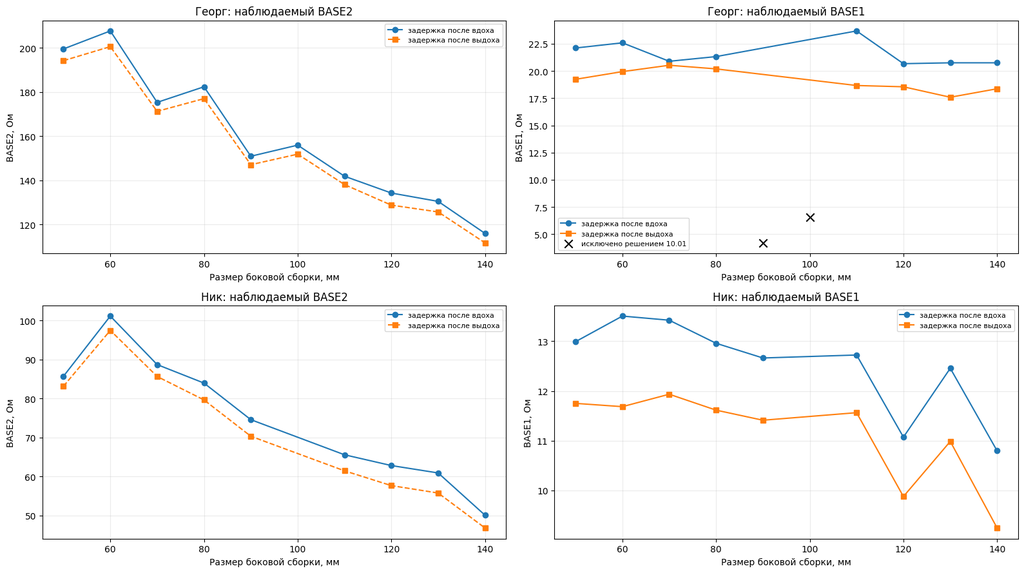

```
Георг: разрешённых BASE1=8; размах/медиана=14.2%; робастный MAD/медиана=2.8%
Ник: разрешённых BASE1=9; размах/медиана=21.3%; робастный MAD/медиана=3.1%
```

## Контроль сердечных циклов RHEO2

Графики исходного `RHEO2` показывают принятые задержки дыхания, точные предельные плато и кандидатные интервалы крупного смещения базовой линии ЭКГ. Амплитуда цикла определяется как разность максимального и минимального значений `RHEO2` между соседними R-зубцами. Это техническая характеристика в мОм, а не восстановленное изменение удельного сопротивления.

Фиксированное ансамблевое окно из конфигурации начинается за 0,15 с до R-зубца и заканчивается через 0,7 с после него. Если следующий R-зубец возникает раньше конца окна, в окно попадает часть следующего сердечного цикла. Такие случаи подсчитываются отдельно и не объявляются пригодными для фиксированного ансамблирования.

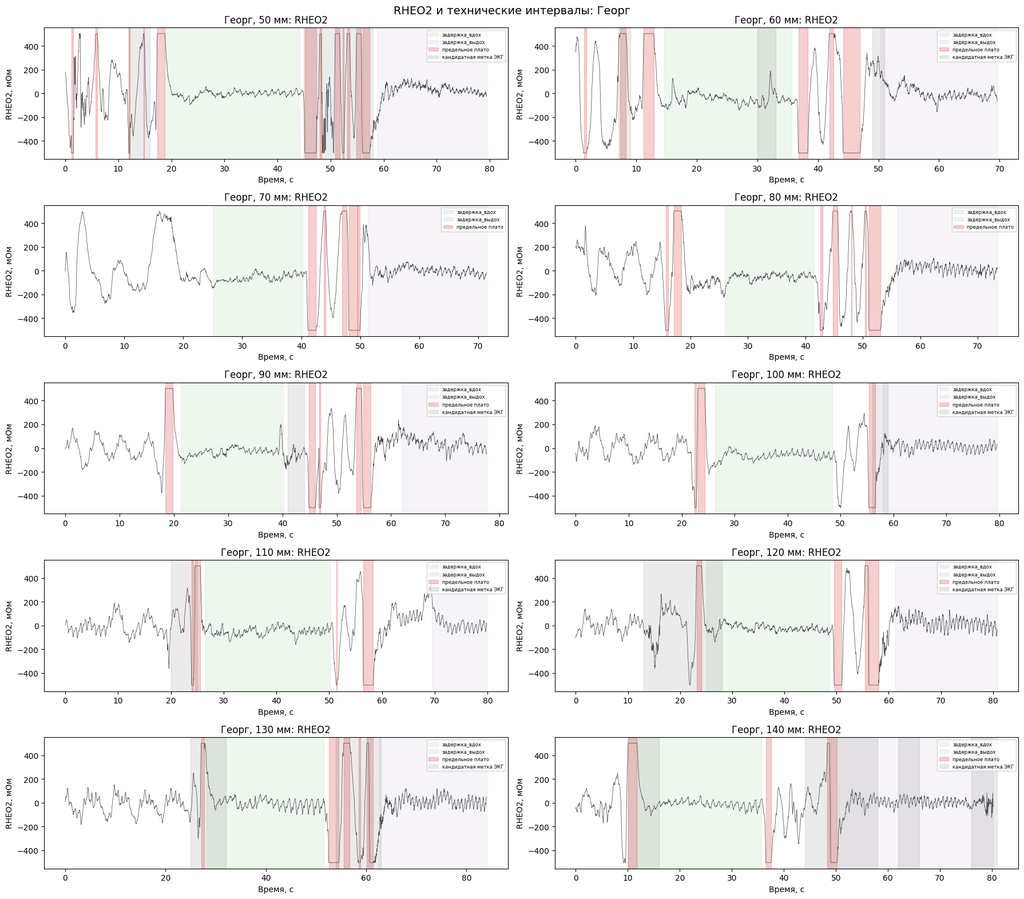

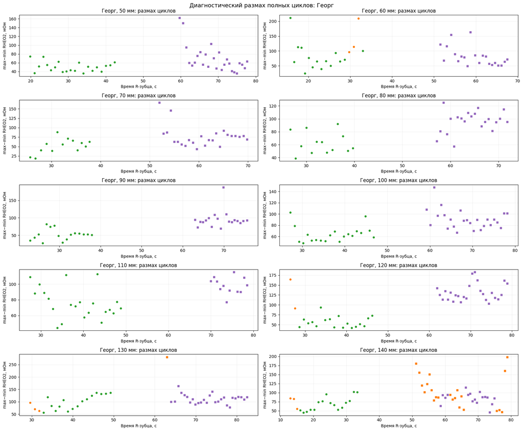

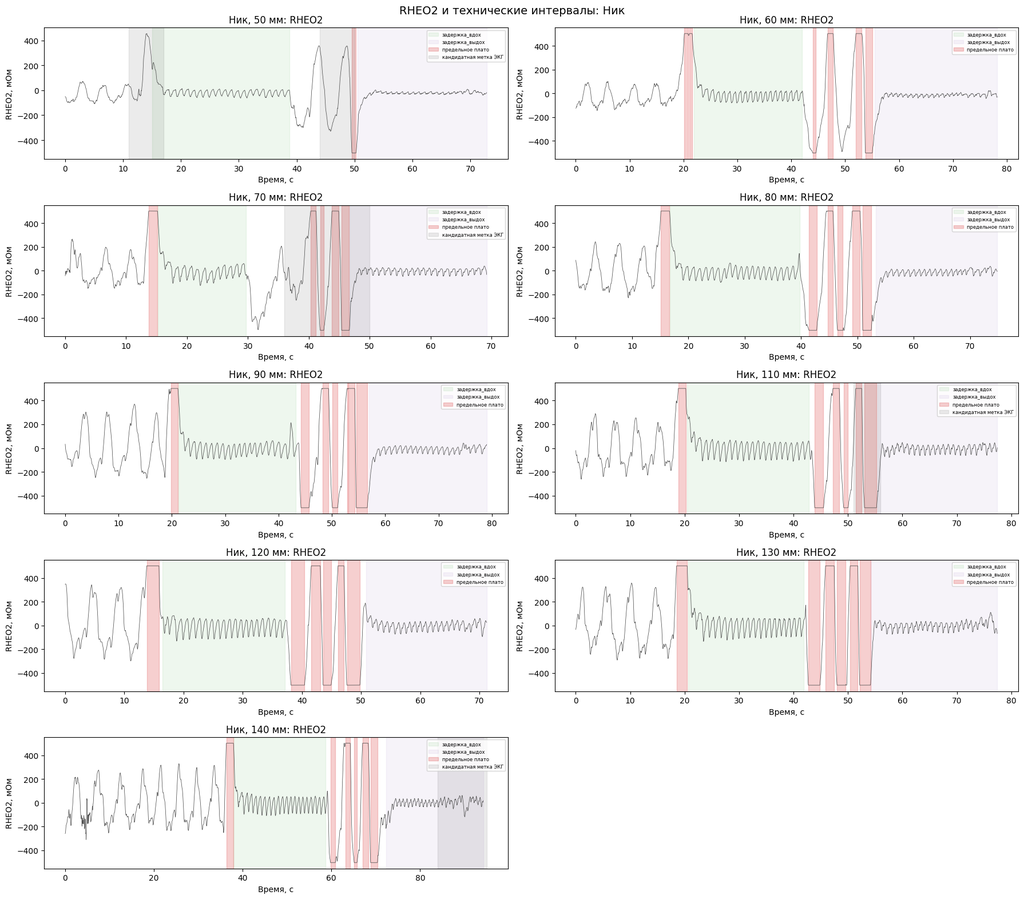

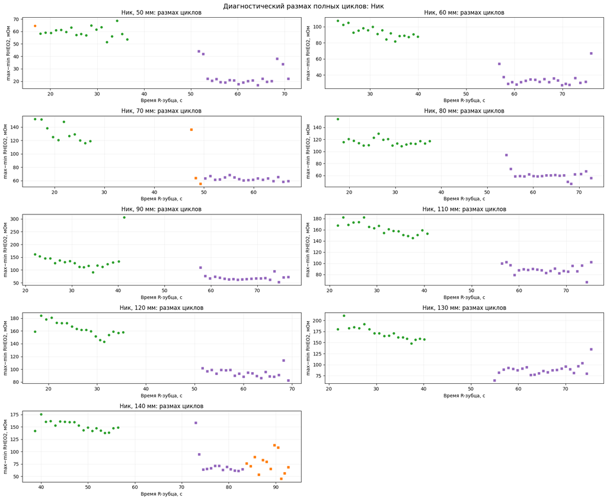

|  | доброволец | размер, мм | всего циклов | с предельным плато | с кандидатной меткой ЭКГ | без предельного плато | без кандидатных интервалов | фиксированное окно пригодно | окно захватывает следующий R | учтено в медиане: вдох | учтено в медиане: выдох | медиана размаха вдох, мОм | медиана размаха выдох, мОм |
| --- | --- | --- | --- | --- | --- | --- | --- | --- | --- | --- | --- | --- | --- |
| 0 | Георг | 50 | 47 | 0 | 0 | 47 | 47 | 38 | 9 | 21 | 26 | 49.8860 | 59.3420 |
| 1 | Георг | 60 | 39 | 0 | 3 | 39 | 36 | 37 | 2 | 18 | 21 | 73.8010 | 71.5800 |
| 2 | Георг | 70 | 37 | 0 | 0 | 37 | 37 | 36 | 0 | 13 | 24 | 55.5700 | 72.3935 |
| 3 | Георг | 80 | 34 | 0 | 0 | 34 | 34 | 30 | 4 | 13 | 21 | 57.8180 | 99.7400 |
| 4 | Георг | 90 | 35 | 0 | 0 | 35 | 35 | 26 | 9 | 16 | 19 | 52.0525 | 91.0090 |
| 5 | Георг | 100 | 45 | 0 | 0 | 45 | 45 | 45 | 0 | 20 | 25 | 61.5725 | 88.9180 |
| 6 | Георг | 110 | 34 | 0 | 0 | 34 | 34 | 32 | 1 | 22 | 12 | 72.8080 | 98.3130 |
| 7 | Георг | 120 | 46 | 0 | 2 | 46 | 44 | 29 | 17 | 20 | 26 | 55.1790 | 125.5610 |
| 8 | Георг | 130 | 47 | 0 | 4 | 47 | 43 | 37 | 9 | 19 | 28 | 96.3990 | 110.3145 |
| 9 | Георг | 140 | 58 | 0 | 25 | 58 | 33 | 44 | 14 | 19 | 39 | 71.3670 | 87.9240 |
| 10 | Ник | 50 | 39 | 0 | 1 | 39 | 38 | 39 | 0 | 19 | 20 | 59.1150 | 20.7805 |
| 11 | Ник | 60 | 39 | 0 | 0 | 39 | 39 | 39 | 0 | 18 | 21 | 92.4035 | 31.9550 |
| 12 | Ник | 70 | 32 | 0 | 3 | 32 | 29 | 32 | 0 | 11 | 21 | 126.9500 | 62.6210 |
| 13 | Ник | 80 | 40 | 0 | 0 | 40 | 40 | 40 | 0 | 20 | 20 | 114.9180 | 60.1540 |
| 14 | Ник | 90 | 39 | 0 | 0 | 39 | 39 | 39 | 0 | 19 | 20 | 129.8070 | 67.0475 |
| 15 | Ник | 110 | 40 | 0 | 0 | 40 | 40 | 40 | 0 | 19 | 21 | 160.9430 | 88.3850 |
| 16 | Ник | 120 | 39 | 0 | 0 | 39 | 39 | 39 | 0 | 19 | 20 | 161.7130 | 93.5245 |
| 17 | Ник | 130 | 42 | 0 | 0 | 42 | 42 | 42 | 0 | 19 | 23 | 170.7350 | 88.4760 |
| 18 | Ник | 140 | 44 | 0 | 12 | 44 | 32 | 43 | 0 | 19 | 25 | 148.5550 | 68.5930 |

```
Сохранён кандидатный результат: 12.01_signal_qc.candidate.json
```

## Интерпретация и передача результата

Сводка разделяет три уровня решения. Принятые дыхательные интервалы и R-зубцы задают временную структуру записи. Точные предельные плато `RHEO2` исключают пересекающиеся циклы из расчёта амплитуды. Интервалы крупного смещения базовой линии ЭКГ пока служат только предупреждающими метками: визуальная проверка `RHEO2` не показала, что все отмеченные циклы являются артефактами.

### Фактический результат проверки

- В принятых задержках дыхания найдено 776 полных интервалов между соседними R-зубцами. Это число относится только к текущей принятой разметке.
- Ни один из этих циклов не пересекает точное предельное плато `RHEO2`. Следовательно, ранее обнаруженные предельные значения находятся за пределами отобранных задержек или не затрагивают вошедшие в анализ циклы.
- С кандидатными интервалами смещения базовой линии ЭКГ пересекаются 50 циклов: 34 у Георга и 16 у Ника. На графиках `RHEO2` часть этих циклов продолжает лежать в основном облаке амплитуд. Поэтому автоматическое исключение всех 50 циклов не принимается; метки сохраняются для последующего контроля формы сигнала.
- Фиксированное окно от −0,15 до +0,7 с относительно R-зубца захватывает следующий R-зубец в 65 циклах Георга и ни в одном цикле Ника. Значит, окно длительностью 0,7 с нельзя считать универсальным для обоих добровольцев. До расчёта усреднённой пульсовой формы требуется выбрать адаптивное окно, зависящее от длительности конкретного интервала R–R, либо нормировать каждый полный цикл по времени.
- Во всех 19 независимых записях наблюдаемый уровень `BASE2` на задержке после вдоха выше уровня на задержке после выдоха. Разность составляет 2,56–7,11 Ом в шкале исходного файла. Это экспериментальное наблюдение, но не восстановленное изменение удельного сопротивления тканей.
- Уровень `BASE2` в целом уменьшается при переходе от малых сборок к большим. Однако размер сборки и порядок записи полностью смешаны, поэтому этот график сам по себе не доказывает причинную зависимость от размера.
- Для разрешённых записей полный межзаписный диапазон `BASE1`, отнесённый к медиане, составляет 14,2 % у Георга и 21,3 % у Ника. Канал 1 нельзя использовать как неизменный внутренний эталон без отдельной модели межзаписной изменчивости. Причина различий по этому расчёту не определяется.

Даже сохранённый цикл пока является технически пригодным кандидатом. Его размах в мОм не интерпретируется как физическое изменение удельного сопротивления без проверки смысла канала, знака, коэффициента усиления и калибровки.

### Решение для следующего этапа

В серию `33` можно передавать принятые задержки дыхания, принятые R-зубцы и полные интервалы R–R, не пересекающие предельные плато. Кандидатные метки смещения базовой линии передаются как флаги, а не как готовые исключения. Фиксированное окно +0,7 с пока не использовать для общего ансамблирования.

Кандидатный результат записывается вне Git в `derived/exp02/qc/12.01_signal_qc.candidate.json`. Перед количественным расчётом пульсовой амплитуды остаются две отдельные задачи: проверить форму и амплитудные выбросы отдельных циклов и обосновать способ временной нормализации сердечного цикла.